# Face Generation

In this project, you'll use generative adversarial networks to generate new images of faces.

### Get the Data

You'll be using two datasets in this project:

- MNIST
- CelebA

Since the celebA dataset is complex and you're doing GANs in a project for the first time, we want you to test your neural network on MNIST before CelebA. Running the GANs on MNIST will allow you to see how well your model trains sooner.

If you're using [FloydHub](https://www.floydhub.com/), set `data_dir` to "/input" and use the [FloydHub data ID](http://docs.floydhub.com/home/using_datasets/) "R5KrjnANiKVhLWAkpXhNBe".

```python
data_dir = './data'

# FloydHub - Use with data ID "R5KrjnANiKVhLWAkpXhNBe"
#data_dir = '/input'


"""
DON'T MODIFY ANYTHING IN THIS CELL
"""
import helper

helper.download_extract('mnist', data_dir)
helper.download_extract('celeba', data_dir)
```

```
Found mnist Data
Found celeba Data
```

## Explore the Data

### MNIST

As you're aware, the [MNIST](http://yann.lecun.com/exdb/mnist/) dataset contains images of handwritten digits. You can view the first number of examples by changing `show_n_images`.

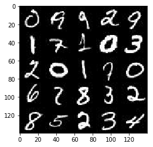

```python
show_n_images = 25

"""
DON'T MODIFY ANYTHING IN THIS CELL
"""
%matplotlib inline
import os
from glob import glob
from matplotlib import pyplot

mnist_images = helper.get_batch(glob(os.path.join(data_dir, 'mnist/*.jpg'))[:show_n_images], 28, 28, 'L')
pyplot.imshow(helper.images_square_grid(mnist_images, 'L'), cmap='gray')
```

### CelebA

The [CelebFaces Attributes Dataset (CelebA)](http://mmlab.ie.cuhk.edu.hk/projects/CelebA.html) dataset contains over 200,000 celebrity images with annotations. Since you're going to be generating faces, you won't need the annotations. You can view the first number of examples by changing `show_n_images`.

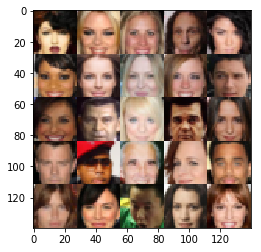

```python
show_n_images = 25

"""
DON'T MODIFY ANYTHING IN THIS CELL
"""
mnist_images = helper.get_batch(glob(os.path.join(data_dir, 'img_align_celeba/*.jpg'))[:show_n_images], 28, 28, 'RGB')
pyplot.imshow(helper.images_square_grid(mnist_images, 'RGB'))
```

## Preprocess the Data

Since the project's main focus is on building the GANs, we'll preprocess the data for you. The values of the MNIST and CelebA dataset will be in the range of -0.5 to 0.5 of 28x28 dimensional images. The CelebA images will be cropped to remove parts of the image that don't include a face, then resized down to 28x28.

The MNIST images are black and white images with a single color channel while the CelebA images have 3 color channels (RGB color channel).

## Build the Neural Network

You'll build the components necessary to build a GANs by implementing the following functions below:

- `model_inputs`
- `discriminator`
- `generator`
- `model_loss`
- `model_opt`
- `train`

### Check the Version of TensorFlow and Access to GPU

This will check to make sure you have the correct version of TensorFlow and access to a GPU

```python
"""
DON'T MODIFY ANYTHING IN THIS CELL
"""
from distutils.version import LooseVersion
import warnings
import tensorflow as tf

# Check TensorFlow Version
assert LooseVersion(tf.__version__) >= LooseVersion('1.0'), 'Please use TensorFlow version 1.0 or newer.  You are using {}'.format(tf.__version__)
print('TensorFlow Version: {}'.format(tf.__version__))

# Check for a GPU
if not tf.test.gpu_device_name():
    warnings.warn('No GPU found. Please use a GPU to train your neural network.')
else:
    print('Default GPU Device: {}'.format(tf.test.gpu_device_name()))
```

```
TensorFlow Version: 1.1.0
```

### Input

Implement the `model_inputs` function to create TF Placeholders for the Neural Network. It should create the following placeholders:

- Real input images placeholder with rank 4 using `image_width`, `image_height`, and `image_channels`.
- Z input placeholder with rank 2 using `z_dim`.
- Learning rate placeholder with rank 0.

Return the placeholders in the following the tuple (tensor of real input images, tensor of z data)

```python
import problem_unittests as tests

def model_inputs(image_width, image_height, image_channels, z_dim):
    """
    Create the model inputs
    :param image_width: The input image width
    :param image_height: The input image height
    :param image_channels: The number of image channels
    :param z_dim: The dimension of Z
    :return: Tuple of (tensor of real input images, tensor of z data, learning rate)
    """
    # TODO: Implement Function
    inputs_real = tf.placeholder(tf.float32,(None, image_width, image_height, image_channels), name='input_real')
    inputs_z = tf.placeholder(tf.float32,(None, z_dim), name='input_z')
    lr = tf.placeholder(tf.float32, name='learning_rate')
    return inputs_real, inputs_z, lr


"""
DON'T MODIFY ANYTHING IN THIS CELL THAT IS BELOW THIS LINE
"""
tests.test_model_inputs(model_inputs)
```

```
Tests Passed
```

### Discriminator

Implement `discriminator` to create a discriminator neural network that discriminates on `images`. This function should be able to reuse the variables in the neural network. Use [`tf.variable_scope`](https://www.tensorflow.org/api_docs/python/tf/variable_scope) with a scope name of "discriminator" to allow the variables to be reused. The function should return a tuple of (tensor output of the discriminator, tensor logits of the discriminator).

```python
def discriminator(images, reuse=False, alpha = 0.2):
    """
    Create the discriminator network
    :param images: Tensor of input image(s)
    :param reuse: Boolean if the weights should be reused
    :return: Tuple of (tensor output of the discriminator, tensor logits of the discriminator)
    """
    # TODO: Implement Function
    with tf.variable_scope('discriminator', reuse=reuse):

        # input layer 28*28*num_channels
        x1 = tf.layers.conv2d(images, 64, 5,strides=2, padding='same')
        relu1 = tf.maximum(alpha * x1, x1)
        # 14*14*64

        x2 = tf.layers.conv2d(relu1, 128, 5, strides=2, padding='same')
        bn2 = tf.layers.batch_normalization(x2, training=True)
        relu2 = tf.maximum(alpha * bn2, bn2)
        # 7*7*128

        x3 = tf.layers.conv2d(relu2, 256, 5, strides=2, padding='same')
        bn3 = tf.layers.batch_normalization(x2, training=True)
        relu3 = tf.maximum(alpha * bn2, bn2)
        # 4*4*256

        # Flatten it
        flat = tf.reshape(relu3, (-1, 4*4*256))
        logits = tf.layers.dense(flat, 1)
        out = tf.sigmoid(logits)

        return out, logits


"""
DON'T MODIFY ANYTHING IN THIS CELL THAT IS BELOW THIS LINE
"""
tests.test_discriminator(discriminator, tf)
```

```
Tests Passed
```

### Generator

Implement `generator` to generate an image using `z`. This function should be able to reuse the variables in the neural network. Use [`tf.variable_scope`](https://www.tensorflow.org/api_docs/python/tf/variable_scope) with a scope name of "generator" to allow the variables to be reused. The function should return the generated 28 x 28 x `out_channel_dim` images.

```python
def generator(z, out_channel_dim, is_train=True, alpha =0.2):
    """
    Create the generator network
    :param z: Input z
    :param out_channel_dim: The number of channels in the output image
    :param is_train: Boolean if generator is being used for training
    :return: The tensor output of the generator
    """
    # TODO: Implement Function
    with tf.variable_scope('generator',reuse= not is_train):
        # First fully connected layer
        x1 = tf.layers.dense(z, 4*4*512)
        # Reshape it to start the convolutional stack
        x1 = tf.reshape(x1, (-1, 4, 4, 512))
        x1 = tf.layers.batch_normalization(x1, training=is_train)
        x1 = tf.maximum(alpha * x1, x1)
        # 4x4x512 now

        # could not use same padding, but found this solution in the udacity forum
        x2 = tf.layers.conv2d_transpose(x1, filters=256, kernel_size=4, strides=1, padding='valid')
        x2 = tf.layers.batch_normalization(x2, training=is_train)
        x2 = tf.maximum(alpha * x2, x2)
        # 7x7x256 now

        x3 = tf.layers.conv2d_transpose(x2, 128, 5, strides=2, padding='same')
        x3 = tf.layers.batch_normalization(x3, training=is_train)
        x3 = tf.maximum(alpha * x3, x3)
        # 14x14x128 now

        # Output layer
        logits = tf.layers.conv2d_transpose(x3, out_channel_dim, 5, strides=2, padding='same')
        # 28x28x out_channel_dim now

        out = tf.tanh(logits)



        return out


"""
DON'T MODIFY ANYTHING IN THIS CELL THAT IS BELOW THIS LINE
"""
tests.test_generator(generator, tf)
```

```
Tests Passed
```

### Loss

Implement `model_loss` to build the GANs for training and calculate the loss. The function should return a tuple of (discriminator loss, generator loss). Use the following functions you implemented:

- `discriminator(images, reuse=False)`
- `generator(z, out_channel_dim, is_train=True)`

```python
def model_loss(input_real, input_z, out_channel_dim, alpha= 0.2):
    """
    Get the loss for the discriminator and generator
    :param input_real: Images from the real dataset
    :param input_z: Z input
    :param out_channel_dim: The number of channels in the output image
    :return: A tuple of (discriminator loss, generator loss)
    """
    # TODO: Implement Function
    g_model = generator(input_z, out_channel_dim, alpha=alpha)
    d_model_real, d_logits_real = discriminator(input_real, alpha=alpha)
    d_model_fake, d_logits_fake = discriminator(g_model, reuse=True, alpha=alpha)

    d_loss_real = tf.reduce_mean(
        tf.nn.sigmoid_cross_entropy_with_logits(logits=d_logits_real, labels=tf.ones_like(d_model_real)))
    d_loss_fake = tf.reduce_mean(
        tf.nn.sigmoid_cross_entropy_with_logits(logits=d_logits_fake, labels=tf.zeros_like(d_model_fake)))
    g_loss = tf.reduce_mean(
        tf.nn.sigmoid_cross_entropy_with_logits(logits=d_logits_fake, labels=tf.ones_like(d_model_fake)))

    d_loss = d_loss_real + d_loss_fake

    return d_loss, g_loss


"""
DON'T MODIFY ANYTHING IN THIS CELL THAT IS BELOW THIS LINE
"""
tests.test_model_loss(model_loss)
```

```
Tests Passed
```

### Optimization

Implement `model_opt` to create the optimization operations for the GANs. Use [`tf.trainable_variables`](https://www.tensorflow.org/api_docs/python/tf/trainable_variables) to get all the trainable variables. Filter the variables with names that are in the discriminator and generator scope names. The function should return a tuple of (discriminator training operation, generator training operation).

```python
def model_opt(d_loss, g_loss, learning_rate, beta1):
    """
    Get optimization operations
    :param d_loss: Discriminator loss Tensor
    :param g_loss: Generator loss Tensor
    :param learning_rate: Learning Rate Placeholder
    :param beta1: The exponential decay rate for the 1st moment in the optimizer
    :return: A tuple of (discriminator training operation, generator training operation)
    """
     # Get weights and bias to update
    t_vars = tf.trainable_variables()
    d_vars = [var for var in t_vars if var.name.startswith('discriminator')]
    g_vars = [var for var in t_vars if var.name.startswith('generator')]

    # Optimize
    with tf.control_dependencies(tf.get_collection(tf.GraphKeys.UPDATE_OPS)):
        d_train_opt = tf.train.AdamOptimizer(learning_rate, beta1=beta1).minimize(d_loss, var_list=d_vars)
        g_train_opt = tf.train.AdamOptimizer(learning_rate, beta1=beta1).minimize(g_loss, var_list=g_vars)

    return d_train_opt, g_train_opt


"""
DON'T MODIFY ANYTHING IN THIS CELL THAT IS BELOW THIS LINE
"""
tests.test_model_opt(model_opt, tf)
```

```
Tests Passed
```

## Neural Network Training

### Show Output

Use this function to show the current output of the generator during training. It will help you determine how well the GANs is training.

```python
"""
DON'T MODIFY ANYTHING IN THIS CELL
"""
import numpy as np

def show_generator_output(sess, n_images, input_z, out_channel_dim, image_mode):
    """
    Show example output for the generator
    :param sess: TensorFlow session
    :param n_images: Number of Images to display
    :param input_z: Input Z Tensor
    :param out_channel_dim: The number of channels in the output image
    :param image_mode: The mode to use for images ("RGB" or "L")
    """
    cmap = None if image_mode == 'RGB' else 'gray'
    z_dim = input_z.get_shape().as_list()[-1]
    example_z = np.random.uniform(-1, 1, size=[n_images, z_dim])

    samples = sess.run(
        generator(input_z, out_channel_dim, False),
        feed_dict={input_z: example_z})

    images_grid = helper.images_square_grid(samples, image_mode)
    pyplot.imshow(images_grid, cmap=cmap)
    pyplot.show()
```

### Train

Implement `train` to build and train the GANs. Use the following functions you implemented:

- `model_inputs(image_width, image_height, image_channels, z_dim)`
- `model_loss(input_real, input_z, out_channel_dim)`
- `model_opt(d_loss, g_loss, learning_rate, beta1)`

Use the `show_generator_output` to show `generator` output while you train. Running `show_generator_output` for every batch will drastically increase training time and increase the size of the notebook. It's recommended to print the `generator` output every 100 batches.

```python
def train(epoch_count, batch_size, z_dim, learning_rate, beta1, get_batches, data_shape, data_image_mode):
    """
    Train the GAN
    :param epoch_count: Number of epochs
    :param batch_size: Batch Size
    :param z_dim: Z dimension
    :param learning_rate: Learning Rate
    :param beta1: The exponential decay rate for the 1st moment in the optimizer
    :param get_batches: Function to get batches
    :param data_shape: Shape of the data
    :param data_image_mode: The image mode to use for images ("RGB" or "L")
    """

    image_width = data_shape[1]
    image_height = data_shape[2]
    out_channel_dim = data_shape[3]

    # TODO: Build Model

    input_real, input_z, lr = model_inputs(image_width, image_height, out_channel_dim, z_dim)
    d_loss, g_loss = model_loss(input_real, input_z,out_channel_dim )
    d_opt, g_opt = model_opt(d_loss, g_loss, learning_rate, beta1)

    with tf.Session() as sess:
        sess.run(tf.global_variables_initializer())
        for epoch_i in range(epoch_count):
            batch_num = 0
            for batch_images in get_batches(batch_size):
                batch_num += 1
                # TODO: Train Model
                batch_z = np.random.uniform(-1,1, size=(batch_size,z_dim))
                batch_images = batch_images * 2
                _ = sess.run(d_opt, feed_dict={input_z: batch_z,input_real: batch_images, lr: learning_rate })
                _ = sess.run(g_opt, feed_dict= {input_z: batch_z, input_real: batch_images, lr: learning_rate })
                if batch_num % 10 == 0:
                    train_loss_d = d_loss.eval({input_z: batch_z, input_real:batch_images})
                    train_loss_g = g_loss.eval({input_z: batch_z})

                    print("Epoch {}, Batch{}...".format(epoch_i, batch_num),
                          "Discriminator Loss: {:.4f}...".format(train_loss_d),
                          "Generator Loss: {:.4f}".format(train_loss_g))

                if batch_num % 100 == 0:
                    show_generator_output(sess, 25, input_z, out_channel_dim, data_image_mode)

        #show output at the end
        show_generator_output(sess, 25, input_z, out_channel_dim, data_image_mode)
```

### MNIST

Test your GANs architecture on MNIST. After 2 epochs, the GANs should be able to generate images that look like handwritten digits. Make sure the loss of the generator is lower than the loss of the discriminator or close to 0.

```
Epoch 0, Batch10... Discriminator Loss: 1.4927... Generator Loss: 0.4908
Epoch 0, Batch20... Discriminator Loss: 1.3089... Generator Loss: 0.6450
Epoch 0, Batch30... Discriminator Loss: 1.2985... Generator Loss: 0.6449
Epoch 0, Batch40... Discriminator Loss: 1.4864... Generator Loss: 0.5822
Epoch 0, Batch50... Discriminator Loss: 1.3604... Generator Loss: 0.6554
Epoch 0, Batch60... Discriminator Loss: 1.2498... Generator Loss: 0.7067
Epoch 0, Batch70... Discriminator Loss: 1.2408... Generator Loss: 0.6991
Epoch 0, Batch80... Discriminator Loss: 1.1905... Generator Loss: 0.7815
Epoch 0, Batch90... Discriminator Loss: 1.1862... Generator Loss: 0.7342
Epoch 0, Batch100... Discriminator Loss: 1.2366... Generator Loss: 0.7357
```

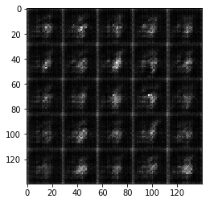

```
Epoch 0, Batch110... Discriminator Loss: 1.2442... Generator Loss: 0.7243
Epoch 0, Batch120... Discriminator Loss: 1.2321... Generator Loss: 0.7472
Epoch 0, Batch130... Discriminator Loss: 1.2441... Generator Loss: 0.7529
Epoch 0, Batch140... Discriminator Loss: 1.1872... Generator Loss: 0.7884
Epoch 0, Batch150... Discriminator Loss: 1.2368... Generator Loss: 0.7809
Epoch 0, Batch160... Discriminator Loss: 1.2365... Generator Loss: 0.7590
Epoch 0, Batch170... Discriminator Loss: 1.2921... Generator Loss: 0.7335
Epoch 0, Batch180... Discriminator Loss: 1.2180... Generator Loss: 0.7590
Epoch 0, Batch190... Discriminator Loss: 1.2463... Generator Loss: 0.7365
Epoch 0, Batch200... Discriminator Loss: 1.2587... Generator Loss: 0.7657
```

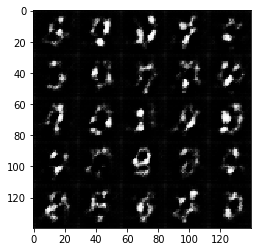

```
Epoch 0, Batch210... Discriminator Loss: 1.2620... Generator Loss: 0.7375
Epoch 0, Batch220... Discriminator Loss: 1.2673... Generator Loss: 0.7561
Epoch 0, Batch230... Discriminator Loss: 1.2355... Generator Loss: 0.7830
Epoch 0, Batch240... Discriminator Loss: 1.2465... Generator Loss: 0.7466
Epoch 0, Batch250... Discriminator Loss: 1.2523... Generator Loss: 0.7697
Epoch 0, Batch260... Discriminator Loss: 1.2641... Generator Loss: 0.7708
Epoch 0, Batch270... Discriminator Loss: 1.2554... Generator Loss: 0.7503
Epoch 0, Batch280... Discriminator Loss: 1.2827... Generator Loss: 0.7390
Epoch 0, Batch290... Discriminator Loss: 1.3125... Generator Loss: 0.7178
Epoch 0, Batch300... Discriminator Loss: 1.2801... Generator Loss: 0.7535
```

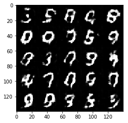

```
Epoch 0, Batch310... Discriminator Loss: 1.2706... Generator Loss: 0.7567
Epoch 0, Batch320... Discriminator Loss: 1.2898... Generator Loss: 0.7410
Epoch 0, Batch330... Discriminator Loss: 1.2444... Generator Loss: 0.7470
Epoch 0, Batch340... Discriminator Loss: 1.2660... Generator Loss: 0.7258
Epoch 0, Batch350... Discriminator Loss: 1.2394... Generator Loss: 0.7916
Epoch 0, Batch360... Discriminator Loss: 1.2704... Generator Loss: 0.7296
Epoch 0, Batch370... Discriminator Loss: 1.2580... Generator Loss: 0.7610
Epoch 0, Batch380... Discriminator Loss: 1.2720... Generator Loss: 0.7531
Epoch 0, Batch390... Discriminator Loss: 1.2385... Generator Loss: 0.7993
Epoch 0, Batch400... Discriminator Loss: 1.2577... Generator Loss: 0.7567
```

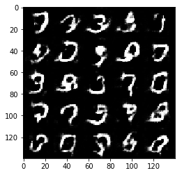

```
Epoch 0, Batch410... Discriminator Loss: 1.2520... Generator Loss: 0.7705
Epoch 0, Batch420... Discriminator Loss: 1.2579... Generator Loss: 0.7359
Epoch 0, Batch430... Discriminator Loss: 1.2381... Generator Loss: 0.7620
Epoch 0, Batch440... Discriminator Loss: 1.2390... Generator Loss: 0.7667
Epoch 0, Batch450... Discriminator Loss: 1.2839... Generator Loss: 0.7282
Epoch 0, Batch460... Discriminator Loss: 1.2036... Generator Loss: 0.7874
Epoch 1, Batch10... Discriminator Loss: 1.2150... Generator Loss: 0.7903
Epoch 1, Batch20... Discriminator Loss: 1.2400... Generator Loss: 0.7932
Epoch 1, Batch30... Discriminator Loss: 1.2049... Generator Loss: 0.7965
Epoch 1, Batch40... Discriminator Loss: 1.2488... Generator Loss: 0.7770
Epoch 1, Batch50... Discriminator Loss: 1.2103... Generator Loss: 0.7510
Epoch 1, Batch60... Discriminator Loss: 1.2142... Generator Loss: 0.8080
Epoch 1, Batch70... Discriminator Loss: 1.1972... Generator Loss: 0.7704
Epoch 1, Batch80... Discriminator Loss: 1.1989... Generator Loss: 0.7972
Epoch 1, Batch90... Discriminator Loss: 1.2303... Generator Loss: 0.7456
Epoch 1, Batch100... Discriminator Loss: 1.2137... Generator Loss: 0.7628
```

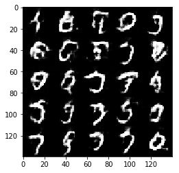

```
Epoch 1, Batch110... Discriminator Loss: 1.2232... Generator Loss: 0.7804
Epoch 1, Batch120... Discriminator Loss: 1.2442... Generator Loss: 0.7520
Epoch 1, Batch130... Discriminator Loss: 1.2453... Generator Loss: 0.7429
Epoch 1, Batch140... Discriminator Loss: 1.2147... Generator Loss: 0.7914
Epoch 1, Batch150... Discriminator Loss: 1.2305... Generator Loss: 0.7308
Epoch 1, Batch160... Discriminator Loss: 1.2397... Generator Loss: 0.7484
Epoch 1, Batch170... Discriminator Loss: 1.2461... Generator Loss: 0.7421
Epoch 1, Batch180... Discriminator Loss: 1.2436... Generator Loss: 0.7722
Epoch 1, Batch190... Discriminator Loss: 1.2313... Generator Loss: 0.7563
Epoch 1, Batch200... Discriminator Loss: 1.1971... Generator Loss: 0.7697
```

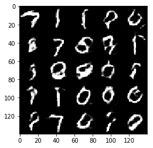

```
Epoch 1, Batch210... Discriminator Loss: 1.2514... Generator Loss: 0.7545
Epoch 1, Batch220... Discriminator Loss: 1.2188... Generator Loss: 0.7847
Epoch 1, Batch230... Discriminator Loss: 1.2187... Generator Loss: 0.7381
Epoch 1, Batch240... Discriminator Loss: 1.1733... Generator Loss: 0.7921
Epoch 1, Batch250... Discriminator Loss: 1.2640... Generator Loss: 0.7709
Epoch 1, Batch260... Discriminator Loss: 1.2096... Generator Loss: 0.7416
Epoch 1, Batch270... Discriminator Loss: 1.2345... Generator Loss: 0.7456
Epoch 1, Batch280... Discriminator Loss: 1.2504... Generator Loss: 0.7376
Epoch 1, Batch290... Discriminator Loss: 1.2657... Generator Loss: 0.7780
Epoch 1, Batch300... Discriminator Loss: 1.2187... Generator Loss: 0.7705
```

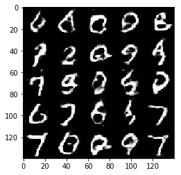

```
Epoch 1, Batch310... Discriminator Loss: 1.2199... Generator Loss: 0.7613
Epoch 1, Batch320... Discriminator Loss: 1.2399... Generator Loss: 0.8892
Epoch 1, Batch330... Discriminator Loss: 1.2148... Generator Loss: 0.8059
Epoch 1, Batch340... Discriminator Loss: 1.2135... Generator Loss: 0.7996
Epoch 1, Batch350... Discriminator Loss: 1.1977... Generator Loss: 0.8177
Epoch 1, Batch360... Discriminator Loss: 1.2090... Generator Loss: 0.8185
Epoch 1, Batch370... Discriminator Loss: 1.2290... Generator Loss: 0.7304
Epoch 1, Batch380... Discriminator Loss: 1.2147... Generator Loss: 0.7773
Epoch 1, Batch390... Discriminator Loss: 1.2097... Generator Loss: 0.7782
Epoch 1, Batch400... Discriminator Loss: 1.3069... Generator Loss: 0.8472
```

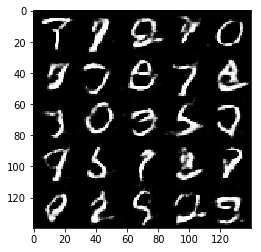

```
Epoch 1, Batch410... Discriminator Loss: 1.2101... Generator Loss: 0.7989
Epoch 1, Batch420... Discriminator Loss: 1.2171... Generator Loss: 0.8246
Epoch 1, Batch430... Discriminator Loss: 1.2227... Generator Loss: 0.7971
Epoch 1, Batch440... Discriminator Loss: 1.2260... Generator Loss: 0.7513
Epoch 1, Batch450... Discriminator Loss: 1.3232... Generator Loss: 0.9899
Epoch 1, Batch460... Discriminator Loss: 1.1422... Generator Loss: 0.7896
```

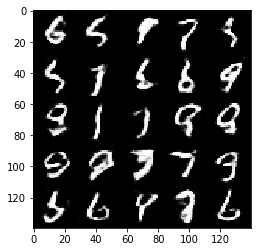

```python
batch_size = 128
z_dim = 100
learning_rate = 0.0002
beta1 = 0.5


"""
DON'T MODIFY ANYTHING IN THIS CELL THAT IS BELOW THIS LINE
"""
epochs = 2

mnist_dataset = helper.Dataset('mnist', glob(os.path.join(data_dir, 'mnist/*.jpg')))
with tf.Graph().as_default():
    train(epochs, batch_size, z_dim, learning_rate, beta1, mnist_dataset.get_batches,
          mnist_dataset.shape, mnist_dataset.image_mode)
```

### CelebA

Run your GANs on CelebA. It will take around 20 minutes on the average GPU to run one epoch. You can run the whole epoch or stop when it starts to generate realistic faces.

```
Epoch 0, Batch10... Discriminator Loss: 1.7931... Generator Loss: 0.4009
Epoch 0, Batch20... Discriminator Loss: 1.5822... Generator Loss: 0.5097
Epoch 0, Batch30... Discriminator Loss: 1.3665... Generator Loss: 0.6431
Epoch 0, Batch40... Discriminator Loss: 1.3081... Generator Loss: 0.7080
Epoch 0, Batch50... Discriminator Loss: 1.1568... Generator Loss: 0.7820
Epoch 0, Batch60... Discriminator Loss: 1.1238... Generator Loss: 0.9313
Epoch 0, Batch70... Discriminator Loss: 0.9377... Generator Loss: 0.9534
Epoch 0, Batch80... Discriminator Loss: 0.9242... Generator Loss: 1.0048
Epoch 0, Batch90... Discriminator Loss: 0.8417... Generator Loss: 1.0820
Epoch 0, Batch100... Discriminator Loss: 0.9194... Generator Loss: 0.9516
```

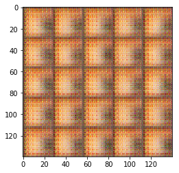

```
Epoch 0, Batch110... Discriminator Loss: 0.8252... Generator Loss: 1.0843
Epoch 0, Batch120... Discriminator Loss: 0.6456... Generator Loss: 1.7463
Epoch 0, Batch130... Discriminator Loss: 0.6033... Generator Loss: 1.4669
Epoch 0, Batch140... Discriminator Loss: 0.6759... Generator Loss: 1.1349
Epoch 0, Batch150... Discriminator Loss: 0.8013... Generator Loss: 0.9278
Epoch 0, Batch160... Discriminator Loss: 0.5169... Generator Loss: 2.0604
Epoch 0, Batch170... Discriminator Loss: 0.6074... Generator Loss: 1.5289
Epoch 0, Batch180... Discriminator Loss: 0.5094... Generator Loss: 1.3420
Epoch 0, Batch190... Discriminator Loss: 0.3985... Generator Loss: 2.0867
Epoch 0, Batch200... Discriminator Loss: 0.3886... Generator Loss: 1.8739
```

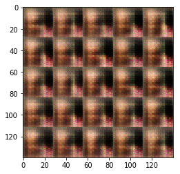

```
Epoch 0, Batch210... Discriminator Loss: 0.4412... Generator Loss: 1.5335
Epoch 0, Batch220... Discriminator Loss: 0.2801... Generator Loss: 2.3805
Epoch 0, Batch230... Discriminator Loss: 0.4118... Generator Loss: 1.6491
Epoch 0, Batch240... Discriminator Loss: 0.4352... Generator Loss: 1.4803
Epoch 0, Batch250... Discriminator Loss: 0.3226... Generator Loss: 2.2114
Epoch 0, Batch260... Discriminator Loss: 0.6505... Generator Loss: 0.9887
Epoch 0, Batch270... Discriminator Loss: 0.3690... Generator Loss: 1.6866
Epoch 0, Batch280... Discriminator Loss: 0.3799... Generator Loss: 1.7489
Epoch 0, Batch290... Discriminator Loss: 0.3446... Generator Loss: 2.4061
Epoch 0, Batch300... Discriminator Loss: 0.4571... Generator Loss: 1.4842
```

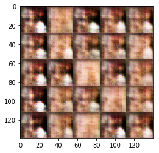

```
Epoch 0, Batch310... Discriminator Loss: 0.7693... Generator Loss: 0.8983
Epoch 0, Batch320... Discriminator Loss: 0.2807... Generator Loss: 3.5173
Epoch 0, Batch330... Discriminator Loss: 0.5085... Generator Loss: 1.6757
Epoch 0, Batch340... Discriminator Loss: 0.6190... Generator Loss: 1.3798
Epoch 0, Batch350... Discriminator Loss: 0.5648... Generator Loss: 1.2743
Epoch 0, Batch360... Discriminator Loss: 0.6720... Generator Loss: 1.4110
Epoch 0, Batch370... Discriminator Loss: 0.5534... Generator Loss: 1.3528
Epoch 0, Batch380... Discriminator Loss: 0.6705... Generator Loss: 1.5713
Epoch 0, Batch390... Discriminator Loss: 0.3895... Generator Loss: 2.2541
Epoch 0, Batch400... Discriminator Loss: 0.6586... Generator Loss: 1.2340
```

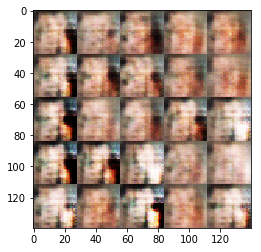

```
Epoch 0, Batch410... Discriminator Loss: 0.4684... Generator Loss: 1.9472
Epoch 0, Batch420... Discriminator Loss: 0.6470... Generator Loss: 1.3367
Epoch 0, Batch430... Discriminator Loss: 0.4484... Generator Loss: 1.8354
Epoch 0, Batch440... Discriminator Loss: 0.4532... Generator Loss: 1.9380
Epoch 0, Batch450... Discriminator Loss: 0.5070... Generator Loss: 1.6941
Epoch 0, Batch460... Discriminator Loss: 0.6843... Generator Loss: 1.8449
Epoch 0, Batch470... Discriminator Loss: 0.6266... Generator Loss: 1.4587
Epoch 0, Batch480... Discriminator Loss: 0.4522... Generator Loss: 2.6493
Epoch 0, Batch490... Discriminator Loss: 0.4904... Generator Loss: 1.9687
Epoch 0, Batch500... Discriminator Loss: 0.6270... Generator Loss: 1.2330
```

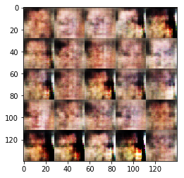

```
Epoch 0, Batch510... Discriminator Loss: 0.7243... Generator Loss: 1.1390
Epoch 0, Batch520... Discriminator Loss: 0.6442... Generator Loss: 1.4302
Epoch 0, Batch530... Discriminator Loss: 0.7442... Generator Loss: 1.0745
Epoch 0, Batch540... Discriminator Loss: 0.5842... Generator Loss: 1.5603
Epoch 0, Batch550... Discriminator Loss: 0.5153... Generator Loss: 1.5411
Epoch 0, Batch560... Discriminator Loss: 0.5944... Generator Loss: 1.4015
Epoch 0, Batch570... Discriminator Loss: 0.6921... Generator Loss: 1.5290
Epoch 0, Batch580... Discriminator Loss: 0.7006... Generator Loss: 1.2990
Epoch 0, Batch590... Discriminator Loss: 0.4805... Generator Loss: 1.8130
Epoch 0, Batch600... Discriminator Loss: 0.6424... Generator Loss: 1.5113
```

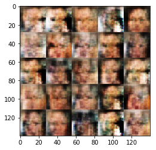

```
Epoch 0, Batch610... Discriminator Loss: 0.7346... Generator Loss: 1.1845
Epoch 0, Batch620... Discriminator Loss: 0.6592... Generator Loss: 1.3418
Epoch 0, Batch630... Discriminator Loss: 0.7202... Generator Loss: 1.1325
Epoch 0, Batch640... Discriminator Loss: 0.8605... Generator Loss: 1.1478
Epoch 0, Batch650... Discriminator Loss: 0.7496... Generator Loss: 1.1520
Epoch 0, Batch660... Discriminator Loss: 0.7903... Generator Loss: 1.2069
Epoch 0, Batch670... Discriminator Loss: 0.8463... Generator Loss: 1.3045
Epoch 0, Batch680... Discriminator Loss: 0.7916... Generator Loss: 1.1019
Epoch 0, Batch690... Discriminator Loss: 0.7211... Generator Loss: 1.3860
Epoch 0, Batch700... Discriminator Loss: 0.7574... Generator Loss: 1.1118
```

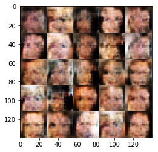

```
Epoch 0, Batch710... Discriminator Loss: 0.8195... Generator Loss: 1.2746
Epoch 0, Batch720... Discriminator Loss: 0.7298... Generator Loss: 1.3512
Epoch 0, Batch730... Discriminator Loss: 0.7730... Generator Loss: 1.4911
Epoch 0, Batch740... Discriminator Loss: 1.0682... Generator Loss: 1.1517
Epoch 0, Batch750... Discriminator Loss: 0.8459... Generator Loss: 1.2043
Epoch 0, Batch760... Discriminator Loss: 0.6253... Generator Loss: 1.4944
Epoch 0, Batch770... Discriminator Loss: 0.8312... Generator Loss: 1.0823
Epoch 0, Batch780... Discriminator Loss: 0.7867... Generator Loss: 1.3890
Epoch 0, Batch790... Discriminator Loss: 0.8985... Generator Loss: 1.2262
Epoch 0, Batch800... Discriminator Loss: 0.7625... Generator Loss: 1.1891
```

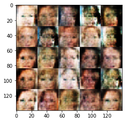

```
Epoch 0, Batch810... Discriminator Loss: 7.3294... Generator Loss: 3.8705
Epoch 0, Batch820... Discriminator Loss: 0.7266... Generator Loss: 1.2854
Epoch 0, Batch830... Discriminator Loss: 0.9468... Generator Loss: 1.0310
Epoch 0, Batch840... Discriminator Loss: 1.1007... Generator Loss: 1.0512
Epoch 0, Batch850... Discriminator Loss: 0.8299... Generator Loss: 1.1713
Epoch 0, Batch860... Discriminator Loss: 0.8426... Generator Loss: 0.9891
Epoch 0, Batch870... Discriminator Loss: 0.7898... Generator Loss: 1.3367
Epoch 0, Batch880... Discriminator Loss: 0.6298... Generator Loss: 1.4511
Epoch 0, Batch890... Discriminator Loss: 0.7520... Generator Loss: 1.3831
Epoch 0, Batch900... Discriminator Loss: 0.8251... Generator Loss: 1.1378
```

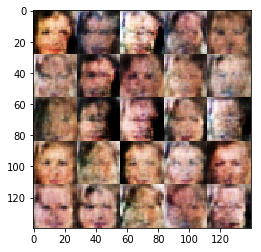

```
Epoch 0, Batch910... Discriminator Loss: 0.7477... Generator Loss: 1.6528
Epoch 0, Batch920... Discriminator Loss: 1.0692... Generator Loss: 1.0317
Epoch 0, Batch930... Discriminator Loss: 0.8663... Generator Loss: 1.3379
Epoch 0, Batch940... Discriminator Loss: 0.8864... Generator Loss: 1.1995
Epoch 0, Batch950... Discriminator Loss: 0.9681... Generator Loss: 0.7824
Epoch 0, Batch960... Discriminator Loss: 1.1870... Generator Loss: 0.9202
Epoch 0, Batch970... Discriminator Loss: 0.8058... Generator Loss: 1.0250
Epoch 0, Batch980... Discriminator Loss: 0.8564... Generator Loss: 1.1865
Epoch 0, Batch990... Discriminator Loss: 1.0020... Generator Loss: 0.8056
Epoch 0, Batch1000... Discriminator Loss: 0.8807... Generator Loss: 1.0703
```

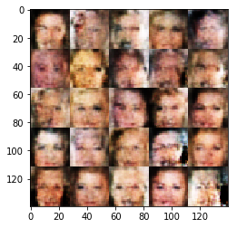

```
Epoch 0, Batch1010... Discriminator Loss: 0.8885... Generator Loss: 1.0399
Epoch 0, Batch1020... Discriminator Loss: 0.8279... Generator Loss: 1.2459
Epoch 0, Batch1030... Discriminator Loss: 0.8270... Generator Loss: 1.5386
Epoch 0, Batch1040... Discriminator Loss: 0.8038... Generator Loss: 1.3963
Epoch 0, Batch1050... Discriminator Loss: 0.6371... Generator Loss: 2.4592
Epoch 0, Batch1060... Discriminator Loss: 0.9711... Generator Loss: 0.9919
Epoch 0, Batch1070... Discriminator Loss: 0.8674... Generator Loss: 1.1598
Epoch 0, Batch1080... Discriminator Loss: 0.5637... Generator Loss: 2.0056
Epoch 0, Batch1090... Discriminator Loss: 1.6972... Generator Loss: 0.7491
Epoch 0, Batch1100... Discriminator Loss: 0.8698... Generator Loss: 1.0269
```

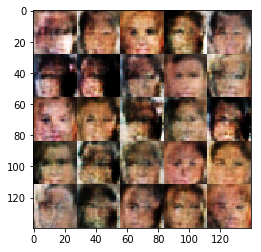

```
Epoch 0, Batch1110... Discriminator Loss: 0.8937... Generator Loss: 1.0495
Epoch 0, Batch1120... Discriminator Loss: 0.9876... Generator Loss: 0.9647
Epoch 0, Batch1130... Discriminator Loss: 0.8745... Generator Loss: 1.1950
Epoch 0, Batch1140... Discriminator Loss: 0.7985... Generator Loss: 1.1181
Epoch 0, Batch1150... Discriminator Loss: 0.8120... Generator Loss: 1.5496
Epoch 0, Batch1160... Discriminator Loss: 0.8470... Generator Loss: 0.9349
Epoch 0, Batch1170... Discriminator Loss: 1.0248... Generator Loss: 0.8033
Epoch 0, Batch1180... Discriminator Loss: 1.0120... Generator Loss: 1.1228
Epoch 0, Batch1190... Discriminator Loss: 0.8689... Generator Loss: 1.3354
Epoch 0, Batch1200... Discriminator Loss: 1.0486... Generator Loss: 1.1143
```

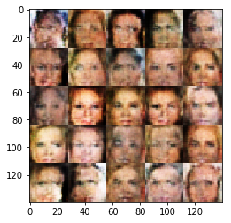

```
Epoch 0, Batch1210... Discriminator Loss: 0.9431... Generator Loss: 0.9198
Epoch 0, Batch1220... Discriminator Loss: 0.7799... Generator Loss: 1.2402
Epoch 0, Batch1230... Discriminator Loss: 0.8314... Generator Loss: 1.2310
Epoch 0, Batch1240... Discriminator Loss: 0.8532... Generator Loss: 1.5203
Epoch 0, Batch1250... Discriminator Loss: 0.9311... Generator Loss: 1.1970
Epoch 0, Batch1260... Discriminator Loss: 0.8495... Generator Loss: 1.4527
Epoch 0, Batch1270... Discriminator Loss: 0.8229... Generator Loss: 1.4709
Epoch 0, Batch1280... Discriminator Loss: 0.6941... Generator Loss: 2.3038
Epoch 0, Batch1290... Discriminator Loss: 0.8675... Generator Loss: 1.2031
Epoch 0, Batch1300... Discriminator Loss: 0.9085... Generator Loss: 1.0465
```

[4 more figures not shown]

```python
batch_size = 128
z_dim = 100
learning_rate = 0.0002
beta1 = 0.5


"""
DON'T MODIFY ANYTHING IN THIS CELL THAT IS BELOW THIS LINE
"""
epochs = 1

celeba_dataset = helper.Dataset('celeba', glob(os.path.join(data_dir, 'img_align_celeba/*.jpg')))
with tf.Graph().as_default():
    train(epochs, batch_size, z_dim, learning_rate, beta1, celeba_dataset.get_batches,
          celeba_dataset.shape, celeba_dataset.image_mode)
```

### Submitting This Project

When submitting this project, make sure to run all the cells before saving the notebook. Save the notebook file as "dlnd_face_generation.ipynb" and save it as a HTML file under "File" -> "Download as". Include the "helper.py" and "problem_unittests.py" files in your submission.